# IE 360 Project Report

### Group 13: Ibrahim Said Bahceci, Ersu Dedeagaoglu

07/06/2022

## Introduction

### Problem Description

In this term project, it is aimed to predict the production value of the next day by using production values up to two days ago and some regressors in the energy production area with a solar panel. The regressors available for 9 different locations are as follows:  
*TEMP: Temperature at the provided location*  
*REL_HUMIDITY: Relative humidity at the provided location*  
*DSWRF: Downward shortwave radiation flux*  
*CLOUD_LOW_LAYER: Total cloud cover data (in terms of percentage) for low-level type of clouds*  
In order to determine appropriate approaches and fit a valid model, output variable (production rate) is analyzed with the time series manner. After determining appropriate models, a comparison is made according to weighted mean absolute percentage errors in a certain time interval.

### Summary of the Proposed Approach

First of all, the imported data was not in a format that could be processed, the "data.table" was brought into a format that is open to manipulation, with a single row for each date. In order to add time series components to the data, trend and seasonality components were examined (can be seen on descriptive analysis). A trend component has been added so that every hour of the day has the same trend value. Added day of the week and month variables to reduce the seasonality effect. The hour factor proved to be the biggest reason for seasonality, so it made sense to set up a different model for each hour. At this point, for the hours whose production value is generally zero, because the margin of error does not increase much and with the thought that simpler approaches can be established, the model was not established for those hours, they were discarded from the data. We preferred to use the last three months for the train phase in order to avoid high variations between seasons. In this way, clear-sky production values, which change over time, which can be considered as the capacity, would not have distorted the model. To introduce the most advanced production value available to the model, we added the lag 72 value to observe its effect. As a result of these iterations, we compared the seasonal autoregressive integrated moving average (SARIMA) model with the model we obtained and thought to work best. Here we used the auto.arima() function to find the correct p,d,q, parameters. These two models were compared in terms of WMAPE values and the model with lower error was selected. However, this model can still produce much more accurate results with further improvements, which is discussed in the conclusion phase.

### Descriptive Analysis

```r
require(readr)
require(tidyverse)
require(dplyr)
require(caTools)
require(rpart)
require(rpart.plot)
require(party)
require(rattle)
require(caret)
require(tree)
require(Metrics)
require(ROCR)
require(ISLR)
require(class)
require(data.table)
require(gridExtra)
require(readxl)
require(ggcorrplot)
require(forecast)
require(writexl)
```

```r
weather <- fread("C://Users//SaidBahçeci//Documents//2022-06-02_weather.csv")
prod <- fread("C://Users//SaidBahçeci//Documents//2022-06-02_production.csv")

str(weather)
str(prod)
```

```
Classes 'data.table' and 'data.frame':	425088 obs. of  6 variables:
 $ date    : IDate, format: "2021-02-01" "2021-02-01" ...
 $ hour    : int  0 1 2 3 4 5 6 7 8 9 ...
 $ lat     : num  36.2 36.2 36.2 36.2 36.2 ...
 $ lon     : num  33 33 33 33 33 33 33 33 33 33 ...
 $ variable: chr  "DSWRF" "DSWRF" "DSWRF" "DSWRF" ...
 $ value   : num  0 0 0 0 0 0 0 0 0 3 ...
 - attr(*, ".internal.selfref")=<externalptr>
Classes 'data.table' and 'data.frame':	11496 obs. of  3 variables:
 $ date      : IDate, format: "2021-02-01" "2021-02-01" ...
 $ hour      : int  0 1 2 3 4 5 6 7 8 9 ...
 $ production: num  0 0 0 0 0 0 0 0 0.189 1.35 ...
 - attr(*, ".internal.selfref")=<externalptr>
```

```r
#transform data from long to wide
weather <- dcast(weather, date + hour ~ variable + lat + lon, value.var = "value")


#adjust date format
weather$date <- as.Date(weather$date, format = "%m/%d/%Y")
prod$date <- as.Date(prod$date, format = "%Y-%m-%d")


#merge weather and production
merged <- merge(weather, prod, by = c("date","hour"), all = T)
merged$hour <- as.factor(merged$hour)
show_na <-merged[is.na(merged$production) & !is.na(merged$CLOUD_LOW_LAYER_36.25_33), ]
```

```r
# fill NA values with the mean of related last three days
for (i in 1:(nrow(merged) - 168)) {
  if(is.na(merged$production[i]))
    merged$production[i] = (merged$production[i-24] + merged$production[i-48] + merged$production[i-72])/3
}
```

[output not shown]

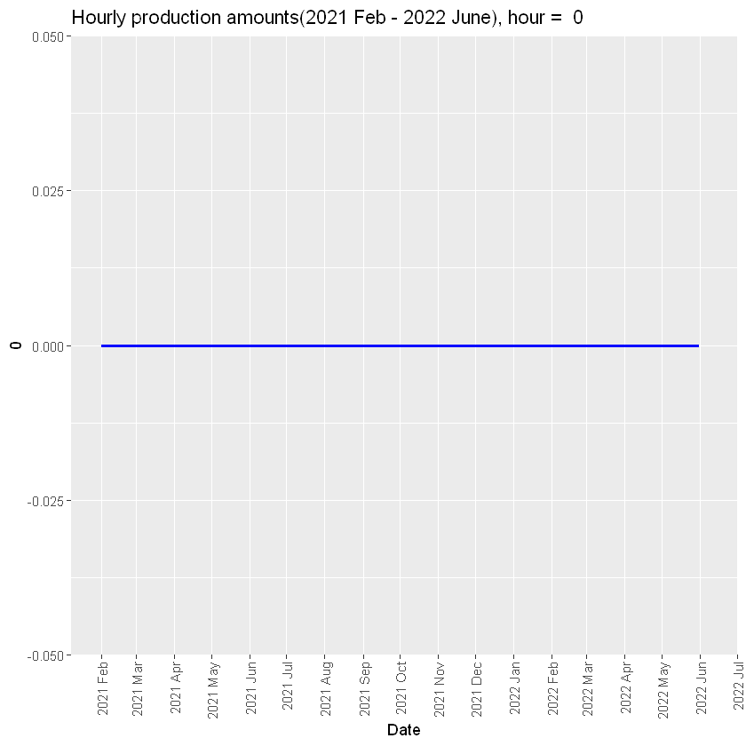

```
Warning message:
"Removed 7 rows containing non-finite values (stat_smooth)."Warning message:
"Removed 7 row(s) containing missing values (geom_path)."
```

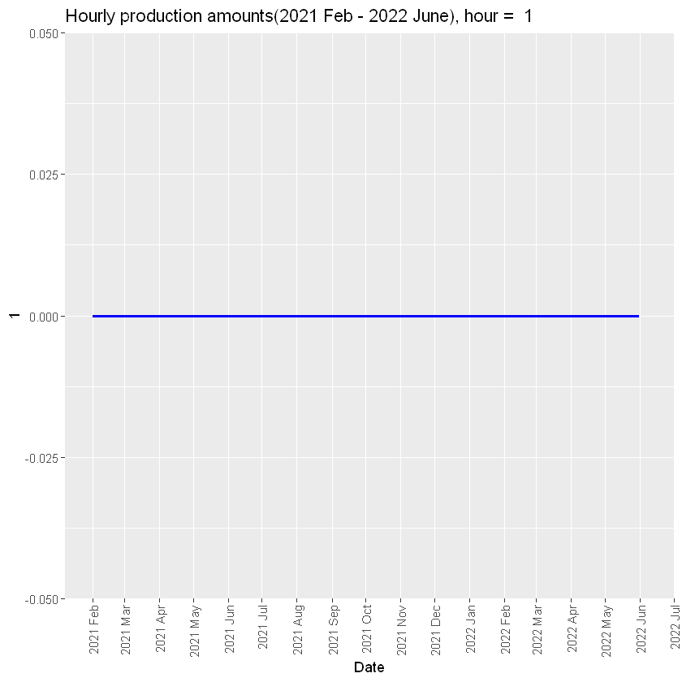

```
Warning message:
"Removed 7 rows containing non-finite values (stat_smooth)."Warning message:
"Removed 7 row(s) containing missing values (geom_path)."
```

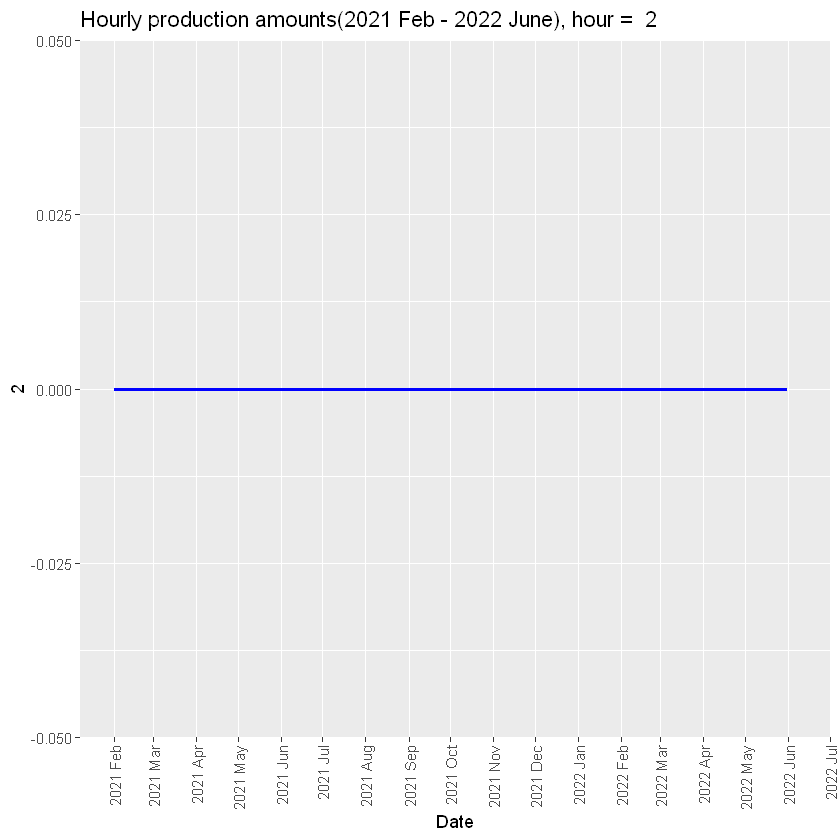

```
Warning message:
"Removed 7 rows containing non-finite values (stat_smooth)."Warning message:
"Removed 7 row(s) containing missing values (geom_path)."
```

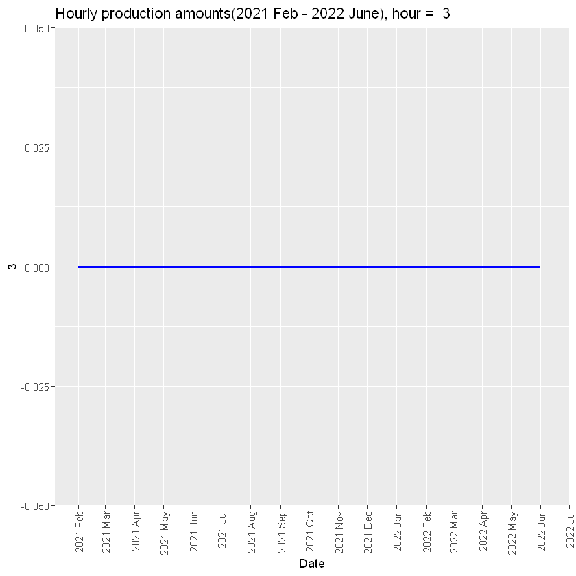

```
Warning message:
"Removed 7 rows containing non-finite values (stat_smooth)."Warning message:
"Removed 7 row(s) containing missing values (geom_path)."
```

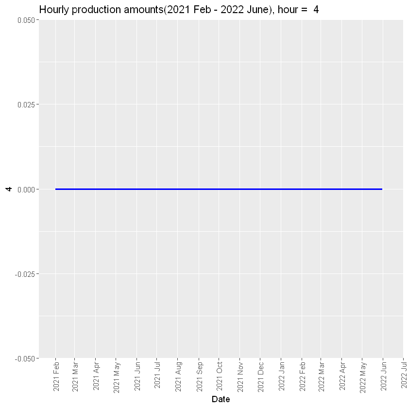

```
Warning message:
"Removed 7 rows containing non-finite values (stat_smooth)."Warning message:
"Removed 7 row(s) containing missing values (geom_path)."
```

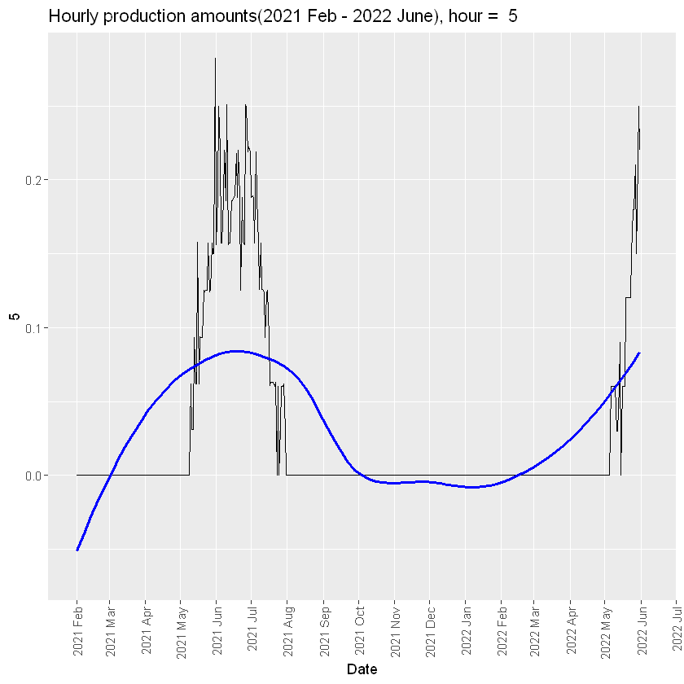

```
Warning message:
"Removed 7 rows containing non-finite values (stat_smooth)."Warning message:
"Removed 7 row(s) containing missing values (geom_path)."
```

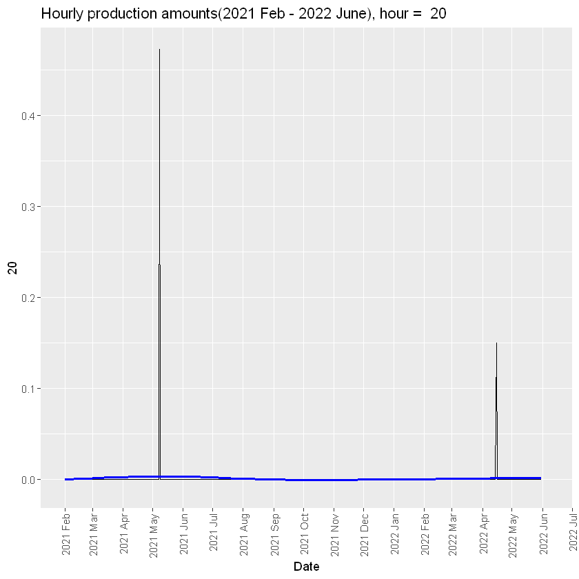

```
Warning message:
"Removed 7 rows containing non-finite values (stat_smooth)."Warning message:
"Removed 7 row(s) containing missing values (geom_path)."
```

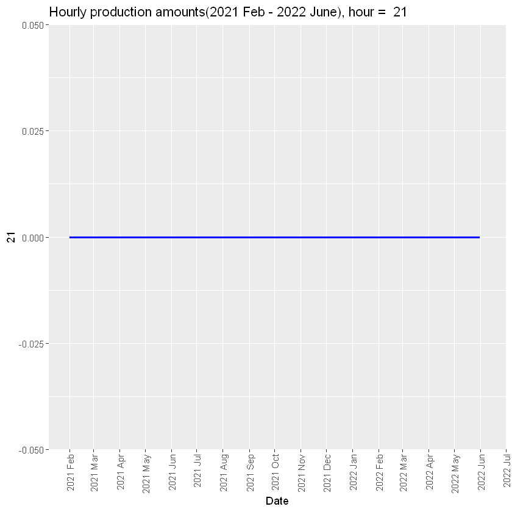

```
Warning message:
"Removed 7 rows containing non-finite values (stat_smooth)."Warning message:
"Removed 7 row(s) containing missing values (geom_path)."
```

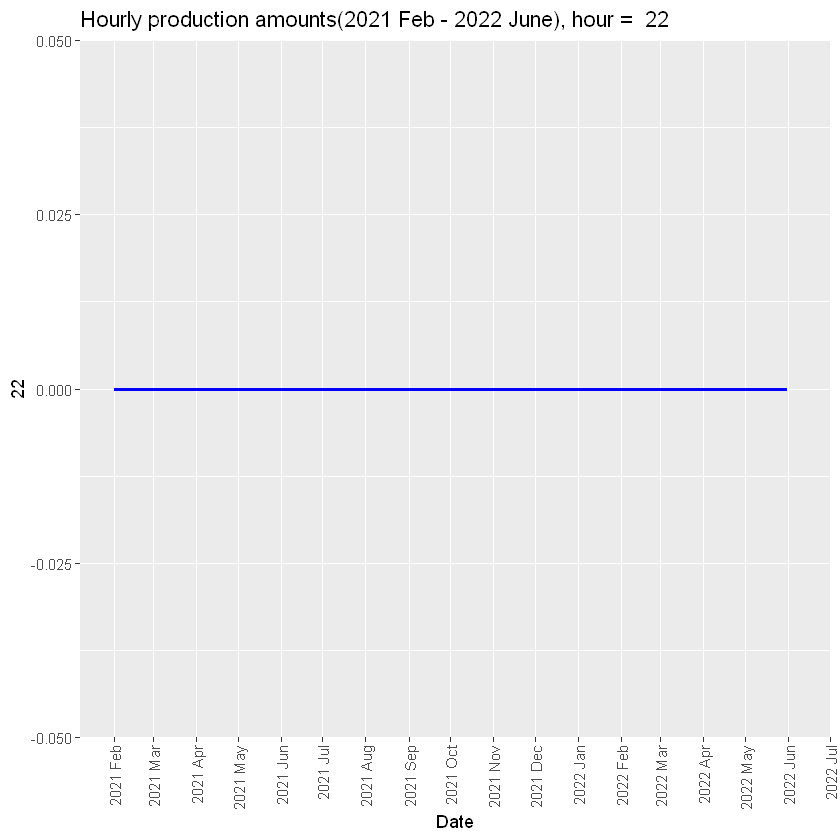

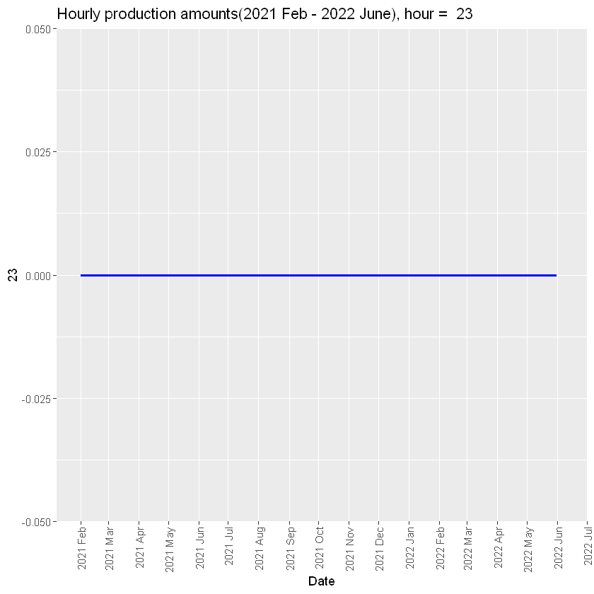

```r
#observe production = 0 hours
merged$date <- as.Date(merged$date)
for (i in c(0:5,20:23)){
  print(ggplot(merged[merged$hour==i,],aes(x=date,y=production)) +  geom_line()+
          xlab("Date") + ylab(i)+ ggtitle(paste("Hourly production amounts(2021 Feb - 2022 June), hour = ",i))+
          scale_x_date(date_breaks = '1 month', date_labels = '%Y %b', date_minor_breaks = '1 month') +
          geom_smooth(color='blue',linetype='solid',fill=NA)+theme(axis.text.x=element_text(angle=90,hjust=1,
                                                                                            vjust = 0.5)))
}
```

Hours with mostly zero production are observed and will be removed from the data, in order not to distort the predictions, and for some possible computational concerns.

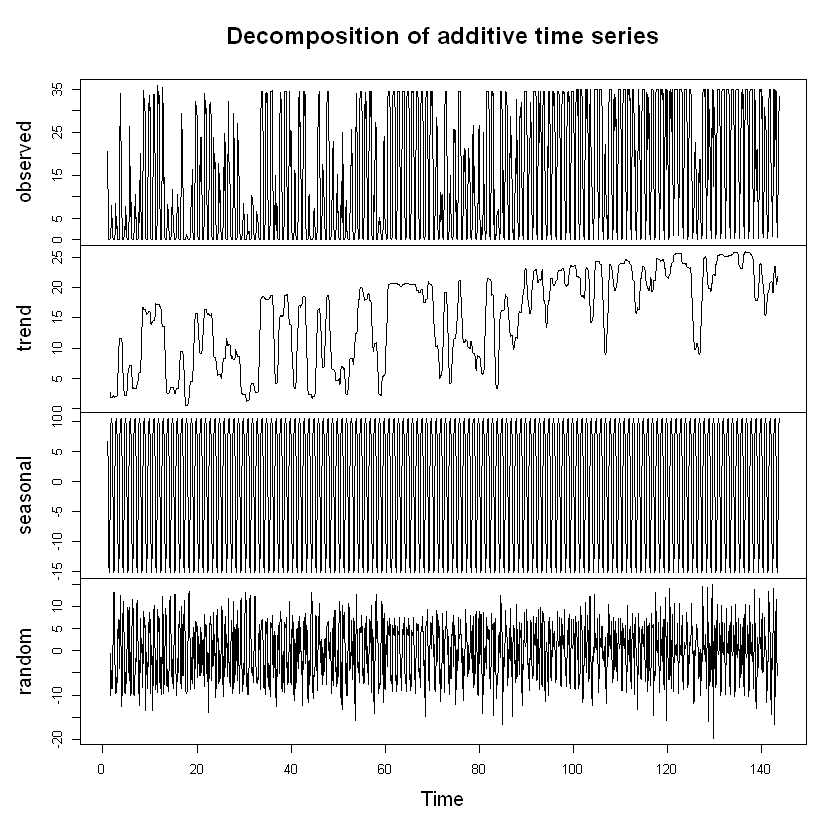

```r
#decomposition
merged2_ts=ts(merged2$production[4000:6000],frequency=14)
plot(decompose(merged2_ts))
```

## Related Literature

According to research, many factors can affect the production efficiency of a solar panel plant. Some of these factors that either decrease or increase the production rate of a solar panel system are temperature, cloud conditions, relative humidity and radiation flux. When most of the solar energy is collected by the panels, which is generally the midday, more production output is expected. That s is why downward shortwave radiation (DSR) has a significant and positively correlated effect on the production rate. Increasing cloud conditions can be said to have a decreasing effect on the production rate, since its limit the capacity of the sun's rays to reach the panel. Temperature also has an effect on the output, because it changes the conductivity of the semiconductor, by changing the balance of charges and magnitude of the electric field. Humidity can restrict energy production from the solar panel, by affecting the performance of modules. In this research, we benefited from the article "FACTORS AFFECTING SOLAR POWER PRODUCTION EFFICIENCY" published by Ericson Gordo, Nashat Khalaf and Tyler Strangeowl.

L. Casula, G. D’Amico and G. Masala who are performed an examination on performance estimation of photovoltaic energy production, state that two climatic variables (temperature and wind speed) and the solar radiation play a significant role on the prediction.

Their study demonstrates that form a model on an hourly basis, yields better result, makes the stochastic process more predictable. Based on this assumption, the solar radiation model is formed with a mixture of Kumaraswamy distributions. Then, the temperature model is formed with the following formula:

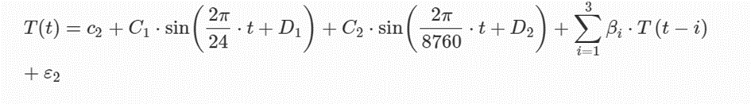

After that, the model that estimates wind speed is formed by following formula:

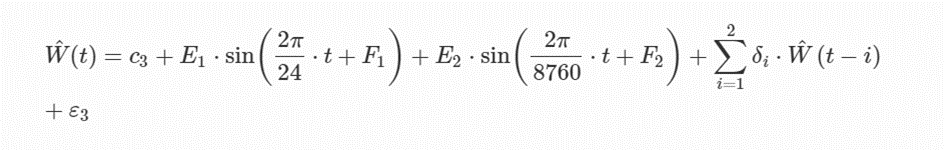

Finally, by using these models, it is shown that the derived simulation yields better result.

## Approach

```r
#assign capacity by observing production values of last 30 days
merged$capacity <- NA
for (i in (30*24):nrow(merged)) {
  for (j in 1:30) {
    merged$capacity[i] <- max(merged$production[seq(i, i - j*24, -24)][!is.na(merged$production[seq(i, i - j*24, -24)])])
  }
}

#since for loop take a while, write_xlsx function is used to gather arranged data
write_xlsx(merged, "merged_06_02.xlsx")
```

```r
#read exported data
merged <- read_xlsx("C:\\Users\\SaidBahçeci\\Documents\\merged_06_02.xlsx")
merged2 <- merged
```

```r
# lag 72 addition (last available data)
merged2$lag72 <- NA
for(i in 1:(nrow(merged2)-72)){
  merged2$lag72[i+72] <- merged2$production[i]
}
```

```r
#substract first month of the data since it does not involve capacity variable
merged2 <- merged2[721:(nrow(merged2) - 20),]
```

```r
#subtract the hours yield production = 0
merged2 <- merged2 %>% filter(hour != 0 & hour != 1 & hour != 2 & hour != 3
                              & hour != 4 & hour != 5 & hour != 20 & hour != 21
                              & hour != 22  & hour != 23)
```

```r
#add weekday and months variable
merged2$weekday <- strftime(merged2$date, format = "%A")
merged2$months <- months(merged2$date)

#factorization and date adjustment
merged2$hour <- as.factor(merged2$hour)
merged2$months <- as.factor(merged2$months)
merged2$weekday <- as.factor(merged2$weekday)
merged2$date <- as.Date(merged2$date)

#assign trend for each day
merged2$trend <- 0
for (i in 1:round(nrow(merged2))) {
  merged2$trend[(i*14-13):(14*i)] <- i
}
merged2$trend <- as.numeric(merged2$trend)
```

## Model 1

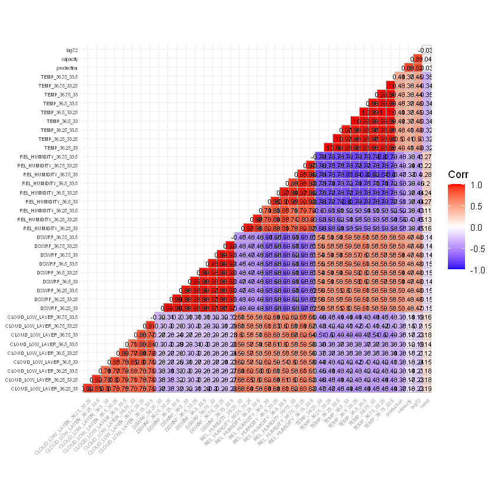

```r
#correlation plot
corr = cor(merged2[1:6370,c(3:41,44)])
ggcorrplot(corr,
           type='lower',
           lab=TRUE,
           tl.cex = 5,
           lab_size = 2.3,
           digits = 2)
```

The correlation plot provides a good insight to determine the input variables that may have a high correlation with the output variable and to observe the correlation values between the input variables. Here, as expected, there is a high correlation between the same variable (temp,wrf,cloud,hum) values from different locations.

```r
#create model that includes all variables
model <- lm(production ~. - date , data = merged2[1:6370,])
summary(model)
```

```
Call:
lm(formula = production ~ . - date, data = merged2[1:6370, ])

Residuals:
    Min      1Q  Median      3Q     Max
-34.762  -2.555   0.953   3.526  18.927

Coefficients:
                              Estimate Std. Error t value Pr(>|t|)
(Intercept)                  2.8723703  7.6656959   0.375 0.707893
hour7                        0.3400262  0.4250032   0.800 0.423709
hour8                        0.8303015  0.5837276   1.422 0.154956
hour9                        0.9855448  0.6783633   1.453 0.146321
hour10                      -4.4076844  0.8200119  -5.375 7.93e-08 ***
hour11                      -5.1528224  0.8548985  -6.027 1.76e-09 ***
hour12                      -5.7401469  0.8838903  -6.494 8.99e-11 ***
hour13                      -6.1712030  0.9046399  -6.822 9.83e-12 ***
hour14                      -7.0291939  0.9143602  -7.688 1.73e-14 ***
hour15                      -7.8128263  0.9048124  -8.635  < 2e-16 ***
hour16                      -6.4986608  0.7986083  -8.137 4.82e-16 ***
hour17                      -5.5581645  0.6391416  -8.696  < 2e-16 ***
hour18                      -4.2350439  0.5339642  -7.931 2.55e-15 ***
hour19                      -3.1948315  0.4855660  -6.580 5.10e-11 ***
CLOUD_LOW_LAYER_36.25_33     0.0035605  0.0075790   0.470 0.638524
CLOUD_LOW_LAYER_36.25_33.25 -0.0081680  0.0092185  -0.886 0.375627
CLOUD_LOW_LAYER_36.25_33.5   0.0013220  0.0076430   0.173 0.862676
CLOUD_LOW_LAYER_36.5_33     -0.0266291  0.0070587  -3.773 0.000163 ***
CLOUD_LOW_LAYER_36.5_33.25  -0.0222968  0.0088431  -2.521 0.011715 *
CLOUD_LOW_LAYER_36.5_33.5   -0.0189863  0.0085525  -2.220 0.026457 *
CLOUD_LOW_LAYER_36.75_33     0.0154858  0.0058715   2.637 0.008374 **
CLOUD_LOW_LAYER_36.75_33.25 -0.0098205  0.0094210  -1.042 0.297262
CLOUD_LOW_LAYER_36.75_33.5   0.0011069  0.0079291   0.140 0.888976
DSWRF_36.25_33              -0.0004222  0.0028945  -0.146 0.884023
DSWRF_36.25_33.25            0.0021988  0.0037322   0.589 0.555781
DSWRF_36.25_33.5            -0.0037929  0.0029348  -1.292 0.196267
DSWRF_36.5_33                0.0085966  0.0027372   3.141 0.001694 **
DSWRF_36.5_33.25            -0.0060333  0.0034479  -1.750 0.080193 .
DSWRF_36.5_33.5              0.0121250  0.0031758   3.818 0.000136 ***
DSWRF_36.75_33               0.0082741  0.0022316   3.708 0.000211 ***
DSWRF_36.75_33.25           -0.0089981  0.0034137  -2.636 0.008412 **
```

[output cut: 30 more lines]

```
monthsJanuary                0.9795053  0.4865009   2.013 0.044118 *
monthsJuly                   1.2172248  0.4901103   2.484 0.013033 *
monthsJune                   0.5530717  0.4412641   1.253 0.210114
monthsMarch                  0.9702952  0.3636162   2.668 0.007640 **
monthsMay                    0.1331929  0.3172896   0.420 0.674658
monthsNovember              -0.8585199  0.4056594  -2.116 0.034354 *
monthsOctober                0.3755675  0.3827699   0.981 0.326540
monthsSeptember              1.0413157  0.4160581   2.503 0.012346 *
trend                        0.0012702  0.0007325   1.734 0.082954 .
---
Signif. codes:  0 '***' 0.001 '**' 0.01 '*' 0.05 '.' 0.1 ' ' 1

Residual standard error: 5.753 on 6300 degrees of freedom
Multiple R-squared:  0.8478,	Adjusted R-squared:  0.8461
F-statistic: 508.5 on 69 and 6300 DF,  p-value: < 2.2e-16
```

Looking at the summary of the first model, it can be seen that the day of the week does not have a significant effect on the production rate. When it comes to lag 72, there seems to be a problem in that the production rate highly depends on even the little changes in the regressors, so the addition of the production rates of three days ago can result in a misleading prediction, especially in extreme conditions.

```
	Breusch-Godfrey test for serial correlation of order up to 73

data:  Residuals
LM test = 3433.9, df = 73, p-value < 2.2e-16
```

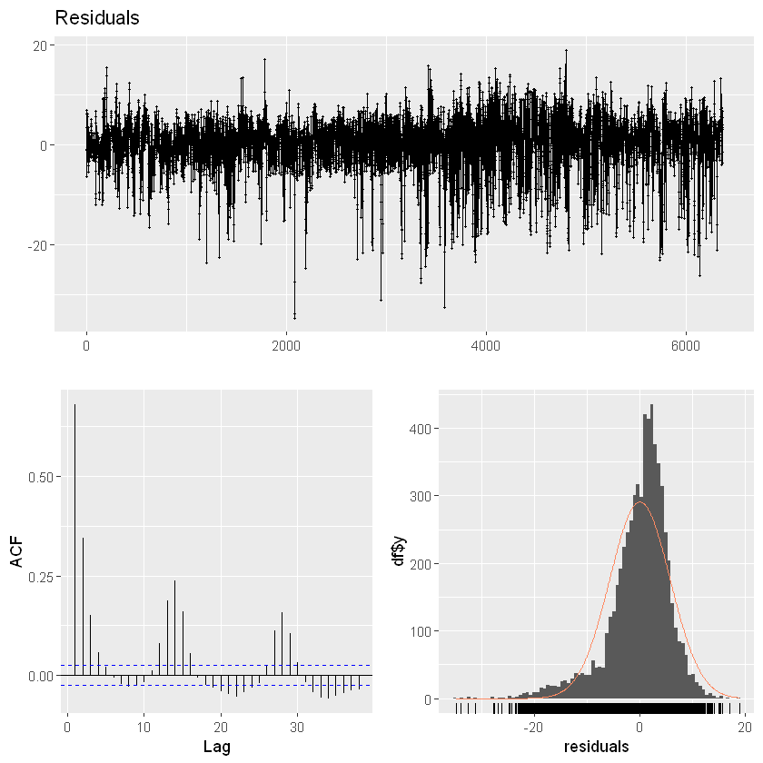

```r
checkresiduals(model)
```

When we look at the residual values, we can talk about a negative bias, especially due to the days when the production values were much lower than expected. Solving this problem does not seem very easy, because there can be many different reasons for slowing down production that cannot be added to the model. Looking at the autocorrelation function, a clear seasonality is seen due to hourly differences. We will talk about the solution to this problem later.

## Model 2

```
Call:
lm(formula = production ~ . - date - weekday - lag72, data = merged2[1:6370,
    ])

Residuals:
    Min      1Q  Median      3Q     Max
-36.592  -2.716   1.104   3.806  20.561

Coefficients:
                              Estimate Std. Error t value Pr(>|t|)
(Intercept)                 -4.5788055  7.7366635  -0.592 0.553984
hour7                        0.3518608  0.4320679   0.814 0.415467
hour8                        0.9141934  0.5933895   1.541 0.123457
hour9                        1.1529382  0.6895208   1.672 0.094557 .
hour10                      -4.4590421  0.8334692  -5.350 9.11e-08 ***
hour11                      -5.2666271  0.8688907  -6.061 1.43e-09 ***
hour12                      -5.9331239  0.8982824  -6.605 4.30e-11 ***
hour13                      -6.4513552  0.9192393  -7.018 2.48e-12 ***
hour14                      -7.5038538  0.9286922  -8.080 7.70e-16 ***
hour15                      -8.4905598  0.9183124  -9.246  < 2e-16 ***
hour16                      -7.2538323  0.8098351  -8.957  < 2e-16 ***
hour17                      -6.2570126  0.6476139  -9.662  < 2e-16 ***
hour18                      -4.7755701  0.5412557  -8.823  < 2e-16 ***
hour19                      -3.6080239  0.4925003  -7.326 2.67e-13 ***
CLOUD_LOW_LAYER_36.25_33     0.0073705  0.0076909   0.958 0.337924
CLOUD_LOW_LAYER_36.25_33.25 -0.0039077  0.0093632  -0.417 0.676439
CLOUD_LOW_LAYER_36.25_33.5  -0.0046977  0.0077509  -0.606 0.544476
CLOUD_LOW_LAYER_36.5_33     -0.0289551  0.0071651  -4.041 5.38e-05 ***
CLOUD_LOW_LAYER_36.5_33.25  -0.0220990  0.0089853  -2.459 0.013941 *
CLOUD_LOW_LAYER_36.5_33.5   -0.0225528  0.0086592  -2.605 0.009222 **
CLOUD_LOW_LAYER_36.75_33     0.0195013  0.0059541   3.275 0.001061 **
CLOUD_LOW_LAYER_36.75_33.25 -0.0132301  0.0095526  -1.385 0.166107
CLOUD_LOW_LAYER_36.75_33.5   0.0073370  0.0080298   0.914 0.360902
DSWRF_36.25_33              -0.0003641  0.0029380  -0.124 0.901385
DSWRF_36.25_33.25            0.0019441  0.0037917   0.513 0.608154
DSWRF_36.25_33.5            -0.0037549  0.0029795  -1.260 0.207627
DSWRF_36.5_33                0.0077861  0.0027775   2.803 0.005074 **
DSWRF_36.5_33.25            -0.0045721  0.0034981  -1.307 0.191254
DSWRF_36.5_33.5              0.0113178  0.0032217   3.513 0.000446 ***
DSWRF_36.75_33               0.0099467  0.0022602   4.401 1.10e-05 ***
```

[output cut: 24 more lines]

```
monthsJanuary                0.5004644  0.4927666   1.016 0.309849
monthsJuly                   1.5104797  0.4970909   3.039 0.002386 **
monthsJune                   0.7295822  0.4482149   1.628 0.103628
monthsMarch                  1.0013675  0.3689927   2.714 0.006670 **
monthsMay                    0.0983328  0.3225029   0.305 0.760449
monthsNovember              -1.3483531  0.4108874  -3.282 0.001038 **
monthsOctober                0.4823192  0.3889245   1.240 0.214971
monthsSeptember              1.2721718  0.4221466   3.014 0.002592 **
trend                        0.0019308  0.0007428   2.599 0.009367 **
---
Signif. codes:  0 '***' 0.001 '**' 0.01 '*' 0.05 '.' 0.1 ' ' 1

Residual standard error: 5.849 on 6307 degrees of freedom
Multiple R-squared:  0.8425,	Adjusted R-squared:  0.841
F-statistic: 544.2 on 62 and 6307 DF,  p-value: < 2.2e-16
```

```
	Breusch-Godfrey test for serial correlation of order up to 66

data:  Residuals
LM test = 3537.7, df = 66, p-value < 2.2e-16
```

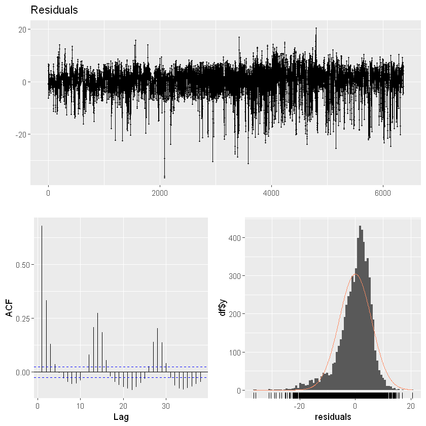

```r
#lag subtraction, since harder to predict extreme cases
#weekday subtraction, since it is unrelated
model2 <- lm(production ~. - date - weekday - lag72 , data = merged2[1:6370,])
summary(model2)
checkresiduals(model2)
```

The fact that hourly factor values have high significance in the model summary and that we saw an hourly seasonality in the autocorrelation function led us to the idea of producing a different model for each hour.

## Model 3

```r
#after observing lag plot and high varying variance, it is meaningful to separate the data with hours and treat them accordingly
h6_merged2 <- merged2 %>%
  filter(hour == 6)
h7_merged2 <- merged2 %>%
  filter(hour == 7)
h8_merged2 <- merged2 %>%
  filter(hour == 8)
h9_merged2 <- merged2 %>%
  filter(hour == 9)
h10_merged2 <- merged2 %>%
  filter(hour == 10)
h11_merged2 <- merged2 %>%
  filter(hour == 11)
h12_merged2 <- merged2 %>%
  filter(hour == 12)
h13_merged2 <- merged2 %>%
  filter(hour == 13)
h14_merged2 <- merged2 %>%
  filter(hour == 14)
h15_merged2 <- merged2 %>%
  filter(hour == 15)
h16_merged2 <- merged2 %>%
  filter(hour == 16)
h17_merged2 <- merged2 %>%
  filter(hour == 17)
h18_merged2 <- merged2 %>%
  filter(hour == 18)
h19_merged2 <- merged2 %>%
  filter(hour == 19)

#subtraction of hour column
h6_merged2 <- h6_merged2[, -2]
h7_merged2 <- h7_merged2[, -2]
h8_merged2 <- h8_merged2[, -2]
h9_merged2 <- h9_merged2[, -2]
h10_merged2 <- h10_merged2[, -2]
h11_merged2 <- h11_merged2[, -2]
h12_merged2 <- h12_merged2[, -2]
h13_merged2 <- h13_merged2[, -2]
h14_merged2 <- h14_merged2[, -2]
h15_merged2 <- h15_merged2[, -2]
h16_merged2 <- h16_merged2[, -2]
h17_merged2 <- h17_merged2[, -2]
h18_merged2 <- h18_merged2[, -2]
h19_merged2 <- h19_merged2[, -2]
```

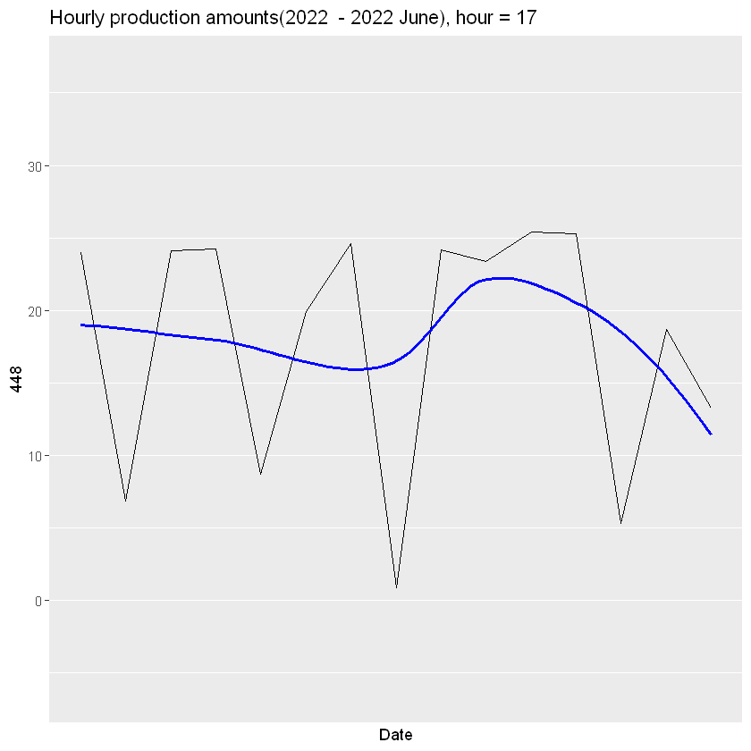

```r
print(ggplot(h17_merged2[434:448,],aes(x=date,y=production)) +  geom_line()+
                  xlab("Date") + ylab(i)+ ggtitle(paste("Hourly production amounts(2022  - 2022 June), hour = 17"))+
                  scale_x_date(date_breaks = '1 month', date_labels = '%Y %b', date_minor_breaks = '1 month') +
                  geom_smooth(color='blue',linetype='solid',fill=NA)+theme(axis.text.x=element_text(angle=90,hjust=1,
                                                                                                    vjust = 0.5)))
```

```
Call:
lm(formula = production ~ . - date - weekday - lag72, data = h8_merged2[364:nrow(h8_merged2 -
    13), ])

Residuals:
     Min       1Q   Median       3Q      Max
-13.0130  -1.6615   0.0125   1.9447   7.0709

Coefficients:
                              Estimate Std. Error t value Pr(>|t|)
(Intercept)                 176.353071  83.225495   2.119   0.0390 *
CLOUD_LOW_LAYER_36.25_33     -0.003719   0.088895  -0.042   0.9668
CLOUD_LOW_LAYER_36.25_33.25   0.160540   0.149516   1.074   0.2880
CLOUD_LOW_LAYER_36.25_33.5   -0.244539   0.120698  -2.026   0.0480 *
CLOUD_LOW_LAYER_36.5_33       0.062740   0.131548   0.477   0.6354
CLOUD_LOW_LAYER_36.5_33.25   -0.010423   0.238693  -0.044   0.9653
CLOUD_LOW_LAYER_36.5_33.5     0.171717   0.117098   1.466   0.1487
CLOUD_LOW_LAYER_36.75_33     -0.017268   0.086839  -0.199   0.8432
CLOUD_LOW_LAYER_36.75_33.25  -0.211190   0.225496  -0.937   0.3534
CLOUD_LOW_LAYER_36.75_33.5    0.079980   0.073642   1.086   0.2826
DSWRF_36.25_33                0.045269   0.463113   0.098   0.9225
DSWRF_36.25_33.25            -0.911935   0.492909  -1.850   0.0701 .
DSWRF_36.25_33.5              0.006442   0.290136   0.022   0.9824
DSWRF_36.5_33                 1.493288   0.655466   2.278   0.0269 *
DSWRF_36.5_33.25             -1.827056   0.694205  -2.632   0.0112 *
DSWRF_36.5_33.5               0.954161   0.530945   1.797   0.0782 .
DSWRF_36.75_33                0.085551   0.213875   0.400   0.6908
DSWRF_36.75_33.25             0.222493   0.682675   0.326   0.7458
DSWRF_36.75_33.5              0.659425   0.415429   1.587   0.1186
REL_HUMIDITY_36.25_33        -0.054121   0.292034  -0.185   0.8537
REL_HUMIDITY_36.25_33.25      0.369300   0.437090   0.845   0.4021
REL_HUMIDITY_36.25_33.5      -0.337533   0.302890  -1.114   0.2703
REL_HUMIDITY_36.5_33         -0.229197   0.286741  -0.799   0.4278
REL_HUMIDITY_36.5_33.25      -0.584747   0.401314  -1.457   0.1512
REL_HUMIDITY_36.5_33.5        0.582308   0.354550   1.642   0.1067
REL_HUMIDITY_36.75_33         0.301326   0.213888   1.409   0.1650
REL_HUMIDITY_36.75_33.25     -0.112342   0.322737  -0.348   0.7292
REL_HUMIDITY_36.75_33.5       0.130601   0.222402   0.587   0.5596
TEMP_36.25_33                 1.470860   2.242138   0.656   0.5148
TEMP_36.25_33.25             -0.330984   3.165768  -0.105   0.9171
TEMP_36.25_33.5              -0.446942   2.303066  -0.194   0.8469
TEMP_36.5_33                 -0.415066   1.575330  -0.263   0.7932
TEMP_36.5_33.25              -2.076228   2.923795  -0.710   0.4809
TEMP_36.5_33.5                3.295339   2.174739   1.515   0.1359
TEMP_36.75_33                -1.310704   1.485381  -0.882   0.3817
TEMP_36.75_33.25              1.773886   2.145248   0.827   0.4122
TEMP_36.75_33.5              -2.037837   1.797996  -1.133   0.2623
capacity                      1.318622   0.516765   2.552   0.0138 *
monthsMarch                   2.180019   3.305592   0.659   0.5125
monthsMay                    -5.963469   3.892292  -1.532   0.1317
trend                        -0.547293   0.208654  -2.623   0.0115 *
---
Signif. codes:  0 '***' 0.001 '**' 0.01 '*' 0.05 '.' 0.1 ' ' 1

Residual standard error: 4.821 on 51 degrees of freedom
  (6 observations deleted due to missingness)
Multiple R-squared:  0.8779,	Adjusted R-squared:  0.7822
F-statistic:  9.17 on 40 and 51 DF,  p-value: 8.865e-13
```

```
	Breusch-Godfrey test for serial correlation of order up to 44

data:  Residuals
LM test = 73.026, df = 44, p-value = 0.003873
```

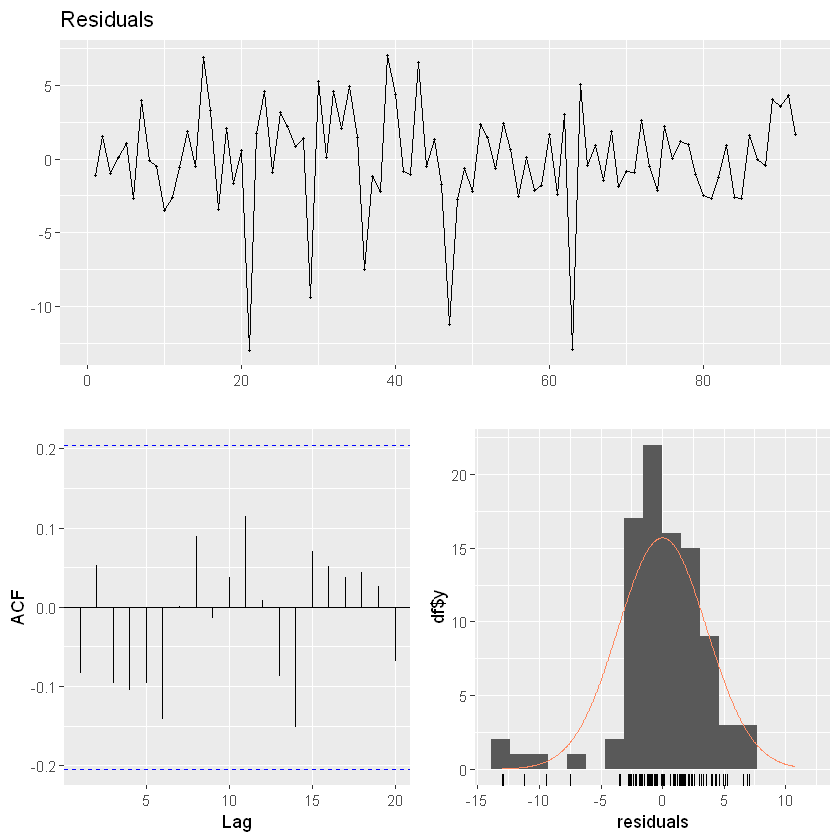

```r
#form model of each hour and observe the significance of variables and check residuals
#while forming model data from March 1 2022 is used to prevent effect of rough weather conditions and high variance
modelh6 <- lm(production ~ . - date - weekday - lag72,
              data = h6_merged2[364:nrow(h6_merged2 - 13),])
#summary(modelh6)
#checkresiduals(modelh6)

modelh7 <- lm(production ~ . - date - weekday - lag72,
              data = h7_merged2[364:nrow(h7_merged2 - 13),])
#summary(modelh7)
#checkresiduals(modelh7)

modelh8 <- lm(production ~ . - date - weekday - lag72,
              data = h8_merged2[364:nrow(h8_merged2 - 13),])
summary(modelh8)
checkresiduals(modelh8)
```

```
Call:
lm(formula = production ~ . - date - weekday - lag72, data = h10_merged2[364:nrow(h10_merged2 -
    13), ])

Residuals:
    Min      1Q  Median      3Q     Max
-6.1689 -1.9234  0.0912  1.6508  7.2649

Coefficients:
                              Estimate Std. Error t value Pr(>|t|)
(Intercept)                 -3.802e+01  5.658e+01  -0.672  0.50467
CLOUD_LOW_LAYER_36.25_33     8.411e-02  7.210e-02   1.167  0.24877
CLOUD_LOW_LAYER_36.25_33.25  5.837e-02  8.390e-02   0.696  0.48972
CLOUD_LOW_LAYER_36.25_33.5  -4.829e-02  5.677e-02  -0.851  0.39897
CLOUD_LOW_LAYER_36.5_33     -1.203e-01  7.136e-02  -1.685  0.09805 .
CLOUD_LOW_LAYER_36.5_33.25  -2.845e-01  2.217e-01  -1.283  0.20526
CLOUD_LOW_LAYER_36.5_33.5    1.272e-01  1.714e-01   0.742  0.46154
CLOUD_LOW_LAYER_36.75_33    -7.041e-04  4.097e-02  -0.017  0.98636
CLOUD_LOW_LAYER_36.75_33.25  1.941e-01  1.202e-01   1.615  0.11258
CLOUD_LOW_LAYER_36.75_33.5  -1.943e-02  6.703e-02  -0.290  0.77308
DSWRF_36.25_33               6.943e-02  2.012e-02   3.451  0.00113 **
DSWRF_36.25_33.25           -4.609e-02  2.616e-02  -1.762  0.08407 .
DSWRF_36.25_33.5             2.736e-02  1.832e-02   1.494  0.14138
DSWRF_36.5_33               -4.464e-03  3.505e-02  -0.127  0.89914
DSWRF_36.5_33.25             5.666e-02  4.140e-02   1.369  0.17710
DSWRF_36.5_33.5             -5.356e-02  2.977e-02  -1.799  0.07793 .
DSWRF_36.75_33              -1.091e-02  3.014e-02  -0.362  0.71896
DSWRF_36.75_33.25            1.012e-02  3.397e-02   0.298  0.76699
DSWRF_36.75_33.5             1.451e-02  2.998e-02   0.484  0.63041
REL_HUMIDITY_36.25_33        3.438e-02  1.727e-01   0.199  0.84298
REL_HUMIDITY_36.25_33.25     6.754e-02  3.048e-01   0.222  0.82552
REL_HUMIDITY_36.25_33.5      2.223e-01  2.570e-01   0.865  0.39112
REL_HUMIDITY_36.5_33        -2.397e-01  1.559e-01  -1.537  0.13049
REL_HUMIDITY_36.5_33.25      3.968e-01  2.484e-01   1.598  0.11627
REL_HUMIDITY_36.5_33.5      -7.187e-01  2.580e-01  -2.785  0.00749 **
REL_HUMIDITY_36.75_33       -1.875e-01  1.807e-01  -1.038  0.30422
REL_HUMIDITY_36.75_33.25     1.975e-01  2.337e-01   0.845  0.40194
REL_HUMIDITY_36.75_33.5      1.936e-01  1.611e-01   1.202  0.23502
TEMP_36.25_33               -1.817e+00  1.455e+00  -1.249  0.21752
TEMP_36.25_33.25             4.286e+00  2.164e+00   1.980  0.05310 .
TEMP_36.25_33.5             -5.502e-01  1.631e+00  -0.337  0.73731
TEMP_36.5_33                -1.501e+00  1.266e+00  -1.186  0.24116
TEMP_36.5_33.25              6.290e-01  1.890e+00   0.333  0.74065
TEMP_36.5_33.5              -3.040e+00  1.229e+00  -2.474  0.01672 *
TEMP_36.75_33               -6.257e-01  1.262e+00  -0.496  0.62207
TEMP_36.75_33.25             3.364e+00  1.791e+00   1.878  0.06610 .
TEMP_36.75_33.5             -4.705e-01  1.351e+00  -0.348  0.72901
capacity                     2.086e+00  9.688e-01   2.153  0.03607 *
monthsMarch                  2.422e+00  2.668e+00   0.908  0.36823
monthsMay                    5.086e+00  2.400e+00   2.119  0.03898 *
trend                       -2.995e-01  7.852e-02  -3.814  0.00037 ***
---
Signif. codes:  0 '***' 0.001 '**' 0.01 '*' 0.05 '.' 0.1 ' ' 1

Residual standard error: 3.336 on 51 degrees of freedom
  (6 observations deleted due to missingness)
Multiple R-squared:  0.8989,	Adjusted R-squared:  0.8196
F-statistic: 11.34 on 40 and 51 DF,  p-value: 1.109e-14
```

```
	Breusch-Godfrey test for serial correlation of order up to 44

data:  Residuals
LM test = 85.478, df = 44, p-value = 0.0001798
```

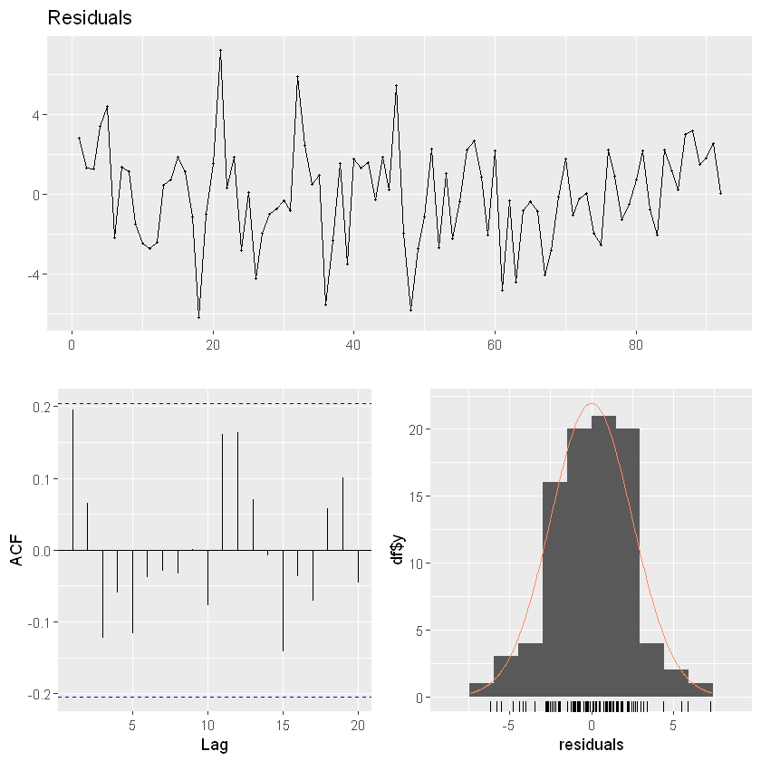

```r
modelh9 <- lm(production ~ . - date - weekday - lag72,
              data = h9_merged2[364:nrow(h9_merged2 - 13),])
#summary(modelh9)
#checkresiduals(modelh9)

modelh10 <- lm(production ~ . - date - weekday - lag72,
               data = h10_merged2[364:nrow(h10_merged2 - 13),])
summary(modelh10)
checkresiduals(modelh10)
```

```
Call:
lm(formula = production ~ . - date - weekday - lag72, data = h14_merged2[364:nrow(h14_merged2 -
    13), ])

Residuals:
   Min     1Q Median     3Q    Max
-8.800 -2.388 -0.110  2.918  7.051

Coefficients:
                              Estimate Std. Error t value Pr(>|t|)
(Intercept)                 -58.821080  86.566193  -0.679  0.49990
CLOUD_LOW_LAYER_36.25_33     -0.091454   0.073423  -1.246  0.21861
CLOUD_LOW_LAYER_36.25_33.25  -0.225432   0.111496  -2.022  0.04845 *
CLOUD_LOW_LAYER_36.25_33.5    0.331953   0.123084   2.697  0.00946 **
CLOUD_LOW_LAYER_36.5_33      -0.007109   0.070421  -0.101  0.91998
CLOUD_LOW_LAYER_36.5_33.25   -0.389943   0.152855  -2.551  0.01378 *
CLOUD_LOW_LAYER_36.5_33.5     0.118246   0.148770   0.795  0.43040
CLOUD_LOW_LAYER_36.75_33     -0.074531   0.060965  -1.223  0.22713
CLOUD_LOW_LAYER_36.75_33.25   0.188407   0.154509   1.219  0.22830
CLOUD_LOW_LAYER_36.75_33.5    0.157741   0.100727   1.566  0.12353
DSWRF_36.25_33                0.015132   0.022214   0.681  0.49883
DSWRF_36.25_33.25            -0.078269   0.033348  -2.347  0.02284 *
DSWRF_36.25_33.5              0.080183   0.034013   2.357  0.02228 *
DSWRF_36.5_33                 0.057591   0.032261   1.785  0.08018 .
DSWRF_36.5_33.25             -0.072319   0.045636  -1.585  0.11922
DSWRF_36.5_33.5               0.004052   0.039691   0.102  0.91909
DSWRF_36.75_33                0.058061   0.023100   2.513  0.01516 *
DSWRF_36.75_33.25            -0.043583   0.041640  -1.047  0.30019
DSWRF_36.75_33.5              0.006044   0.025931   0.233  0.81665
REL_HUMIDITY_36.25_33         0.463136   0.248663   1.863  0.06830 .
REL_HUMIDITY_36.25_33.25     -0.053030   0.377596  -0.140  0.88887
REL_HUMIDITY_36.25_33.5      -0.116717   0.287652  -0.406  0.68662
REL_HUMIDITY_36.5_33         -0.355304   0.157755  -2.252  0.02864 *
REL_HUMIDITY_36.5_33.25       0.466805   0.323246   1.444  0.15482
REL_HUMIDITY_36.5_33.5       -1.004045   0.360734  -2.783  0.00753 **
REL_HUMIDITY_36.75_33         0.491237   0.258875   1.898  0.06342 .
REL_HUMIDITY_36.75_33.25     -0.454439   0.368625  -1.233  0.22331
REL_HUMIDITY_36.75_33.5       0.278274   0.305413   0.911  0.36651
TEMP_36.25_33                 1.682696   1.700300   0.990  0.32702
TEMP_36.25_33.25             -0.733945   2.163878  -0.339  0.73587
TEMP_36.25_33.5              -0.952439   1.759889  -0.541  0.59073
TEMP_36.5_33                 -3.590267   1.867554  -1.922  0.06014 .
TEMP_36.5_33.25               2.500853   1.954603   1.279  0.20652
TEMP_36.5_33.5               -0.604609   1.613276  -0.375  0.70938
TEMP_36.75_33                 1.327400   1.871780   0.709  0.48145
TEMP_36.75_33.25             -2.023672   2.162234  -0.936  0.35373
TEMP_36.75_33.5               2.733541   1.943568   1.406  0.16565
capacity                      1.659793   1.485018   1.118  0.26894
monthsMarch                   0.656450   3.794518   0.173  0.86334
monthsMay                     2.562408   3.472185   0.738  0.46391
trend                        -0.200847   0.111482  -1.802  0.07752 .
---
Signif. codes:  0 '***' 0.001 '**' 0.01 '*' 0.05 '.' 0.1 ' ' 1

Residual standard error: 4.999 on 51 degrees of freedom
  (6 observations deleted due to missingness)
Multiple R-squared:  0.7744,	Adjusted R-squared:  0.5974
F-statistic: 4.376 on 40 and 51 DF,  p-value: 5.885e-07
```

```
	Breusch-Godfrey test for serial correlation of order up to 44

data:  Residuals
LM test = 82.149, df = 44, p-value = 0.0004269
```

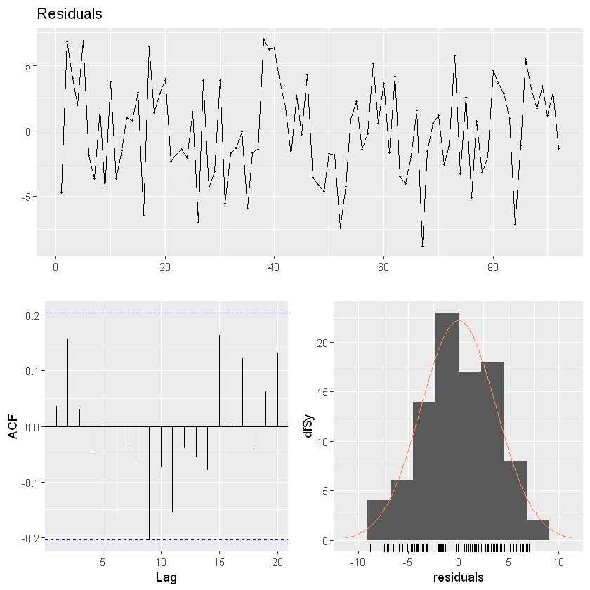

```r
modelh11 <- lm(production ~ . - date - weekday - lag72,
               data = h11_merged2[364:nrow(h11_merged2 - 13),])
#summary(modelh11)
#checkresiduals(modelh11)

modelh12 <- lm(production ~ . - date - weekday - lag72,
               data = h12_merged2[364:nrow(h12_merged2 - 13),])
#summary(modelh12)
#checkresiduals(modelh12)

modelh13 <- lm(production ~ . - date - weekday - lag72,
               data = h13_merged2[364:nrow(h13_merged2 - 13),])
#summary(modelh13)
#checkresiduals(modelh13)

modelh14 <- lm(production ~ . - date - weekday - lag72,
               data = h14_merged2[364:nrow(h14_merged2 - 13),])
summary(modelh14)
checkresiduals(modelh14)
```

```
Call:
lm(formula = production ~ . - date - weekday - lag72, data = h16_merged2[364:nrow(h16_merged2 -
    13), ])

Residuals:
     Min       1Q   Median       3Q      Max
-15.3374  -3.0267   0.0111   2.8794  11.3845

Coefficients:
                             Estimate Std. Error t value Pr(>|t|)
(Intercept)                 185.49566  133.44149   1.390 0.170539
CLOUD_LOW_LAYER_36.25_33      0.13839    0.08363   1.655 0.104111
CLOUD_LOW_LAYER_36.25_33.25  -0.01455    0.08531  -0.171 0.865223
CLOUD_LOW_LAYER_36.25_33.5   -0.06816    0.07213  -0.945 0.349135
CLOUD_LOW_LAYER_36.5_33      -0.17351    0.04946  -3.508 0.000951 ***
CLOUD_LOW_LAYER_36.5_33.25    0.01787    0.04746   0.376 0.708111
CLOUD_LOW_LAYER_36.5_33.5    -0.02041    0.06376  -0.320 0.750192
CLOUD_LOW_LAYER_36.75_33      0.01389    0.05156   0.269 0.788731
CLOUD_LOW_LAYER_36.75_33.25  -0.01719    0.07802  -0.220 0.826495
CLOUD_LOW_LAYER_36.75_33.5    0.13258    0.06991   1.897 0.063563 .
DSWRF_36.25_33                0.03295    0.02204   1.495 0.141139
DSWRF_36.25_33.25             0.01029    0.02286   0.450 0.654610
DSWRF_36.25_33.5             -0.01506    0.01687  -0.892 0.376398
DSWRF_36.5_33                -0.05847    0.01845  -3.169 0.002587 **
DSWRF_36.5_33.25              0.01495    0.02156   0.693 0.491262
DSWRF_36.5_33.5               0.03349    0.02357   1.421 0.161364
DSWRF_36.75_33                0.03222    0.01360   2.370 0.021623 *
DSWRF_36.75_33.25            -0.01845    0.01913  -0.965 0.339280
DSWRF_36.75_33.5              0.00840    0.02091   0.402 0.689651
REL_HUMIDITY_36.25_33         0.04316    0.32167   0.134 0.893784
REL_HUMIDITY_36.25_33.25      0.56725    0.56609   1.002 0.321049
REL_HUMIDITY_36.25_33.5      -0.58633    0.49536  -1.184 0.242045
REL_HUMIDITY_36.5_33         -0.04546    0.24878  -0.183 0.855721
REL_HUMIDITY_36.5_33.25       0.06205    0.44210   0.140 0.888932
REL_HUMIDITY_36.5_33.5       -0.23179    0.43185  -0.537 0.593783
REL_HUMIDITY_36.75_33        -0.19361    0.37018  -0.523 0.603230
REL_HUMIDITY_36.75_33.25     -0.40283    0.54319  -0.742 0.461730
REL_HUMIDITY_36.75_33.5       0.37676    0.36177   1.041 0.302574
TEMP_36.25_33                 1.89849    2.27316   0.835 0.407513
TEMP_36.25_33.25             -0.93577    3.72136  -0.251 0.802470
TEMP_36.25_33.5              -0.89404    2.90688  -0.308 0.759669
TEMP_36.5_33                  0.30986    2.74264   0.113 0.910492
TEMP_36.5_33.25              -3.02173    3.68925  -0.819 0.416561
TEMP_36.5_33.5               -1.79000    2.48887  -0.719 0.475299
TEMP_36.75_33                 0.58252    2.82342   0.206 0.837365
TEMP_36.75_33.25             -0.14718    2.70412  -0.054 0.956806
TEMP_36.75_33.5               3.70893    2.47268   1.500 0.139789
capacity                      0.37216    1.07912   0.345 0.731609
monthsMarch                   3.94118    3.98235   0.990 0.327012
monthsMay                     5.55570    4.38628   1.267 0.211050
trend                        -0.20089    0.15877  -1.265 0.211498
---
Signif. codes:  0 '***' 0.001 '**' 0.01 '*' 0.05 '.' 0.1 ' ' 1

Residual standard error: 6.352 on 51 degrees of freedom
  (6 observations deleted due to missingness)
Multiple R-squared:  0.8175,	Adjusted R-squared:  0.6743
F-statistic: 5.711 on 40 and 51 DF,  p-value: 6.969e-09
```

```
	Breusch-Godfrey test for serial correlation of order up to 44

data:  Residuals
LM test = 86.037, df = 44, p-value = 0.0001551
```

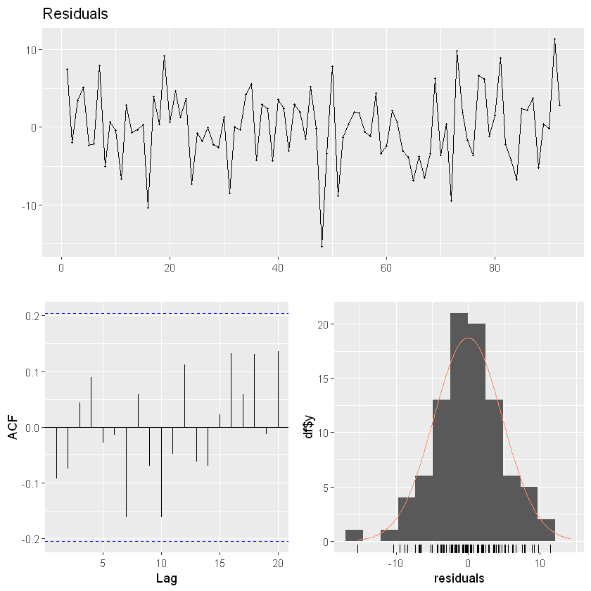

```r
modelh15 <- lm(production ~ . - date - weekday - lag72,
               data = h15_merged2[364:nrow(h15_merged2 - 13),])
#summary(modelh15)
#checkresiduals(modelh15)

modelh16 <- lm(production ~ . - date - weekday - lag72,
               data = h16_merged2[364:nrow(h16_merged2 - 13),])
summary(modelh16)
checkresiduals(modelh16)
```

```
Call:
lm(formula = production ~ . - date - weekday - lag72, data = h19_merged2[364:nrow(h19_merged2 -
    13), ])

Residuals:
     Min       1Q   Median       3Q      Max
-0.53514 -0.09124 -0.01608  0.10144  0.58693

Coefficients:
                              Estimate Std. Error t value Pr(>|t|)
(Intercept)                  5.228e+00  3.827e+00   1.366  0.17793
CLOUD_LOW_LAYER_36.25_33     6.582e-03  3.556e-03   1.851  0.06994 .
CLOUD_LOW_LAYER_36.25_33.25 -8.247e-03  4.423e-03  -1.864  0.06802 .
CLOUD_LOW_LAYER_36.25_33.5   2.779e-03  3.817e-03   0.728  0.46984
CLOUD_LOW_LAYER_36.5_33     -1.442e-03  2.268e-03  -0.636  0.52780
CLOUD_LOW_LAYER_36.5_33.25  -2.552e-03  2.154e-03  -1.184  0.24171
CLOUD_LOW_LAYER_36.5_33.5   -5.722e-03  3.969e-03  -1.442  0.15552
CLOUD_LOW_LAYER_36.75_33    -1.771e-03  1.948e-03  -0.909  0.36761
CLOUD_LOW_LAYER_36.75_33.25  3.247e-03  4.352e-03   0.746  0.45907
CLOUD_LOW_LAYER_36.75_33.5   6.161e-03  4.422e-03   1.393  0.16955
DSWRF_36.25_33               6.082e-05  1.232e-03   0.049  0.96081
DSWRF_36.25_33.25            5.090e-05  1.451e-03   0.035  0.97215
DSWRF_36.25_33.5            -4.503e-04  1.197e-03  -0.376  0.70830
DSWRF_36.5_33                2.127e-03  1.255e-03   1.695  0.09625 .
DSWRF_36.5_33.25            -3.612e-03  1.433e-03  -2.521  0.01485 *
DSWRF_36.5_33.5              4.354e-04  1.253e-03   0.347  0.72966
DSWRF_36.75_33              -2.581e-03  1.068e-03  -2.416  0.01930 *
DSWRF_36.75_33.25            5.949e-03  1.586e-03   3.752  0.00045 ***
DSWRF_36.75_33.5            -1.404e-03  1.511e-03  -0.929  0.35715
REL_HUMIDITY_36.25_33        1.487e-02  1.104e-02   1.347  0.18397
REL_HUMIDITY_36.25_33.25    -2.217e-04  1.861e-02  -0.012  0.99054
REL_HUMIDITY_36.25_33.5     -1.183e-02  1.319e-02  -0.897  0.37403
REL_HUMIDITY_36.5_33         1.743e-02  1.019e-02   1.710  0.09328 .
REL_HUMIDITY_36.5_33.25     -3.279e-02  1.721e-02  -1.906  0.06232 .
REL_HUMIDITY_36.5_33.5      -1.650e-03  1.326e-02  -0.124  0.90146
REL_HUMIDITY_36.75_33       -1.018e-02  1.021e-02  -0.997  0.32358
REL_HUMIDITY_36.75_33.25     2.413e-02  1.676e-02   1.439  0.15614
REL_HUMIDITY_36.75_33.5     -2.199e-03  9.910e-03  -0.222  0.82527
TEMP_36.25_33               -2.777e-02  7.274e-02  -0.382  0.70422
TEMP_36.25_33.25             2.014e-01  1.328e-01   1.516  0.13575
TEMP_36.25_33.5             -1.795e-01  9.076e-02  -1.978  0.05338 .
TEMP_36.5_33                 6.405e-02  5.684e-02   1.127  0.26505
TEMP_36.5_33.25             -1.230e-01  1.016e-01  -1.210  0.23181
TEMP_36.5_33.5               2.699e-02  9.959e-02   0.271  0.78750
TEMP_36.75_33                2.841e-03  6.046e-02   0.047  0.96270
TEMP_36.75_33.25             8.907e-02  1.088e-01   0.819  0.41682
TEMP_36.75_33.5             -5.457e-02  7.406e-02  -0.737  0.46460
capacity                     5.602e-01  1.255e-01   4.462  4.5e-05 ***
monthsMarch                 -6.664e-02  1.679e-01  -0.397  0.69315
monthsMay                    5.052e-01  1.554e-01   3.251  0.00204 **
trend                       -1.278e-02  6.989e-03  -1.829  0.07325 .
---
Signif. codes:  0 '***' 0.001 '**' 0.01 '*' 0.05 '.' 0.1 ' ' 1

Residual standard error: 0.2221 on 51 degrees of freedom
  (6 observations deleted due to missingness)
Multiple R-squared:  0.8565,	Adjusted R-squared:  0.744
F-statistic: 7.613 on 40 and 51 DF,  p-value: 3.488e-11
```

```
	Breusch-Godfrey test for serial correlation of order up to 44

data:  Residuals
LM test = 77.87, df = 44, p-value = 0.001239
```

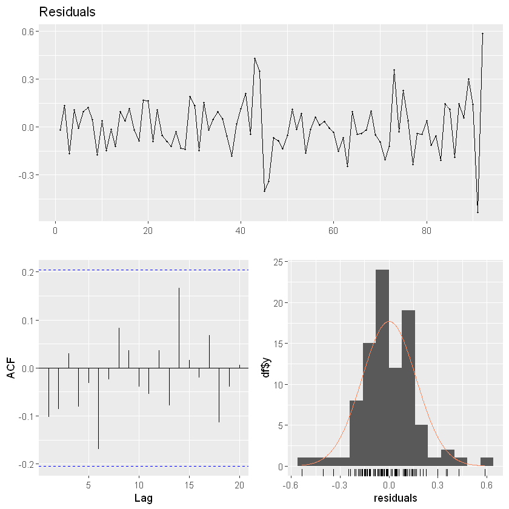

```r
modelh17 <- lm(production ~ . - date - weekday - lag72,
               data = h17_merged2[364:nrow(h17_merged2 - 13),])
#summary(modelh17)
#checkresiduals(modelh17)

modelh18 <- lm(production ~ . - date - weekday - lag72,
               data = h18_merged2[364:nrow(h18_merged2 - 13),])
#summary(modelh18)
#checkresiduals(modelh18)

modelh19 <- lm(production ~ . - date - weekday - lag72,
               data = h19_merged2[364:nrow(h19_merged2 - 13),])
summary(modelh19)
checkresiduals(modelh19)
```

### Prediction of Model 3

```r
#prediction of the last linear model
pred1 <- c()
for (i in c(364 : 448)) {
  pred1[(i-363)*14 -13] = predict(modelh6,newdata=h6_merged2[i,])
  pred1[(i-363)*14 -12] = predict(modelh7,newdata=h7_merged2[i,])
  pred1[(i-363)*14 -11] = predict(modelh8,newdata=h8_merged2[i,])
  pred1[(i-363)*14 -10] = predict(modelh9,newdata=h9_merged2[i,])
  pred1[(i-363)*14 -9] = predict(modelh10,newdata=h10_merged2[i,])
  pred1[(i-363)*14 -8] = predict(modelh11,newdata=h11_merged2[i,])
  pred1[(i-363)*14 -7] = predict(modelh12,newdata=h12_merged2[i,])
  pred1[(i-363)*14 -6] = predict(modelh13,newdata=h13_merged2[i,])
  pred1[(i-363)*14 -5] = predict(modelh14,newdata=h14_merged2[i,])
  pred1[(i-363)*14 -4] = predict(modelh15,newdata=h15_merged2[i,])
  pred1[(i-363)*14 -3] = predict(modelh16,newdata=h16_merged2[i,])
  pred1[(i-363)*14 -2] = predict(modelh17,newdata=h17_merged2[i,])
  pred1[(i-363)*14 -1] = predict(modelh18,newdata=h18_merged2[i,])
  pred1[(i-363)*14] = predict(modelh19,newdata=h19_merged2[i,])
}

#assign 0 for negative values
pred1[pred1 < 0] = 0

#WMAPE calculation
actual = merged2$production[5083:6272]
wmape1 = sum(abs(pred1-actual))/sum(actual)
```

## Model Sarima

```r
#sarima alternative
sarima_model=auto.arima(merged2_ts,seasonal=T,stepwise=T,approximation=T,trace=T)

#WMAPE calculation
wmape2 = sum(abs(sarima_model[["residuals"]]))/sum(actual)
```

```
 Fitting models using approximations to speed things up...

 ARIMA(2,0,2)(1,1,1)[14] with drift         : 6943.492
 ARIMA(0,0,0)(0,1,0)[14] with drift         : 8545.584
 ARIMA(1,0,0)(1,1,0)[14] with drift         : 7261.685
 ARIMA(0,0,1)(0,1,1)[14] with drift         : 7263.595
 ARIMA(0,0,0)(0,1,0)[14]                    : 8544.112
 ARIMA(2,0,2)(0,1,1)[14] with drift         : Inf
 ARIMA(2,0,2)(1,1,0)[14] with drift         : Inf
 ARIMA(2,0,2)(2,1,1)[14] with drift         : 6961.123
 ARIMA(2,0,2)(1,1,2)[14] with drift         : 6938.07
 ARIMA(2,0,2)(0,1,2)[14] with drift         : Inf
 ARIMA(2,0,2)(2,1,2)[14] with drift         : Inf
 ARIMA(1,0,2)(1,1,2)[14] with drift         : 6935.085
 ARIMA(1,0,2)(0,1,2)[14] with drift         : 6968.284
 ARIMA(1,0,2)(1,1,1)[14] with drift         : 6940.443
 ARIMA(1,0,2)(2,1,2)[14] with drift         : 6959.998
 ARIMA(1,0,2)(0,1,1)[14] with drift         : 6966.734
 ARIMA(1,0,2)(2,1,1)[14] with drift         : 6972.841
 ARIMA(0,0,2)(1,1,2)[14] with drift         : 7043.939
 ARIMA(1,0,1)(1,1,2)[14] with drift         : 6933.172
 ARIMA(1,0,1)(0,1,2)[14] with drift         : 6966.314
 ARIMA(1,0,1)(1,1,1)[14] with drift         : 6938.92
 ARIMA(1,0,1)(2,1,2)[14] with drift         : 6958.451
 ARIMA(1,0,1)(0,1,1)[14] with drift         : 6964.753
 ARIMA(1,0,1)(2,1,1)[14] with drift         : 6971.21
 ARIMA(0,0,1)(1,1,2)[14] with drift         : 7256.46
 ARIMA(1,0,0)(1,1,2)[14] with drift         : 6952.939
 ARIMA(2,0,1)(1,1,2)[14] with drift         : 6936.135
 ARIMA(0,0,0)(1,1,2)[14] with drift         : 7956.585
 ARIMA(2,0,0)(1,1,2)[14] with drift         : 6934.586
 ARIMA(1,0,1)(1,1,2)[14]                    : 6935.385

 Now re-fitting the best model(s) without approximations...

 ARIMA(1,0,1)(1,1,2)[14] with drift         : Inf
 ARIMA(2,0,0)(1,1,2)[14] with drift         : Inf
 ARIMA(1,0,2)(1,1,2)[14] with drift         : Inf
 ARIMA(1,0,1)(1,1,2)[14]                    : Inf
 ARIMA(2,0,1)(1,1,2)[14] with drift         : Inf
 ARIMA(2,0,2)(1,1,2)[14] with drift         : Inf
 ARIMA(1,0,1)(1,1,1)[14] with drift         : Inf
 ARIMA(1,0,2)(1,1,1)[14] with drift         : Inf
 ARIMA(2,0,2)(1,1,1)[14] with drift         : Inf
 ARIMA(1,0,0)(1,1,2)[14] with drift         : Inf
 ARIMA(1,0,1)(2,1,2)[14] with drift         : Inf
 ARIMA(1,0,2)(2,1,2)[14] with drift         : Inf
 ARIMA(2,0,2)(2,1,1)[14] with drift         : Inf
 ARIMA(1,0,1)(0,1,1)[14] with drift         : Inf
 ARIMA(1,0,1)(0,1,2)[14] with drift         : Inf
 ARIMA(1,0,2)(0,1,1)[14] with drift         : Inf
 ARIMA(1,0,2)(0,1,2)[14] with drift         : Inf
 ARIMA(1,0,1)(2,1,1)[14] with drift         : Inf
 ARIMA(1,0,2)(2,1,1)[14] with drift         : Inf
 ARIMA(0,0,2)(1,1,2)[14] with drift         : Inf
 ARIMA(0,0,1)(1,1,2)[14] with drift         : Inf
 ARIMA(1,0,0)(1,1,0)[14] with drift         : 7331.494

 Best model: ARIMA(1,0,0)(1,1,0)[14] with drift
```

### Comparison of WMAPE's of Model 3 and SARIMA

```r
#data frame of WMAPE's
data.frame("Method" = c("Linear Regression","SARIMA"), "WMAPE" = c(wmape1, wmape2))
```

| Method | WMAPE |
| --- | --- |
| Linear Regression | 0.1101942 |
| SARIMA | 0.1697785 |

## Results

After all these iterations of preparing data, manipulating, visualizing and extracting insight, adding and removing regressors, and identifying alternative models, it was observed that the models prepared by dividing by hours worked best. At this stage, we did not attempt to remove any variable from the model from any location, as we think it is a risky approach. For such a decision, we think that it would be useful to examine the production facility geographically and to benefit from the views of scientists. Besides, we think the biggest shortcoming of the model is that it still doesn't catch the unexpectedly large production rate drops.

## Conclusions and Future Work

As a result, in line with the steps we mentioned above, we tried to predict the next day's production values in a solar energy production plant. For this, the data was examined with time series analysis, the necessary components were added, and a different forecasting model was created for each hour, considering that the production values depend too much on the hour factor (both intiutive and data-driven decision). In order not to be affected by the changes in the clear-sky (capacity) values and the high variation of output values between seasons, only a part of the available data was used for training. The resulting model compared the SARIMA model in terms of WMAPE and it was seen that the hourly models made better predictions. At this point, as we mentioned in the results area, two issues that require further examination are as follows:

1) Some locations may be unrelevant to the production: At this stage, we did not want to exclude any variable in any location from the model. We thought that this should not be just a data-driven decision, but a decision that should be made considering the geographical structure of the region. For this reason, some regressors can be removed from the model by making new studies in this direction. Also, it would be better if these studies are done separately for each different hour model.

2) Unexpected big drops in production rate: For a reason not found in regressors, very large decreases in production value can cause high increases in WMAPE value because they cannot be detected by the model. For this reason, it may be necessary to examine the causes of such sudden drops that may occur in a production facility with a more scientific approach and add new regressors that can catch these drops. Such an approach will also largely solve the bias problem in errors.